# ACT-USD

## ACT-USD today is +0200, 2025-10-30, 17:47:04

This crypto forecast was generated by gemini-2.0-flash API

## Daily Chart

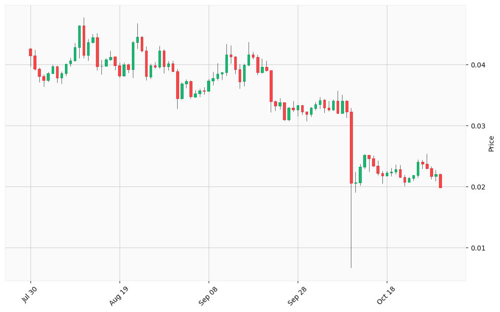

## Hourly Chart

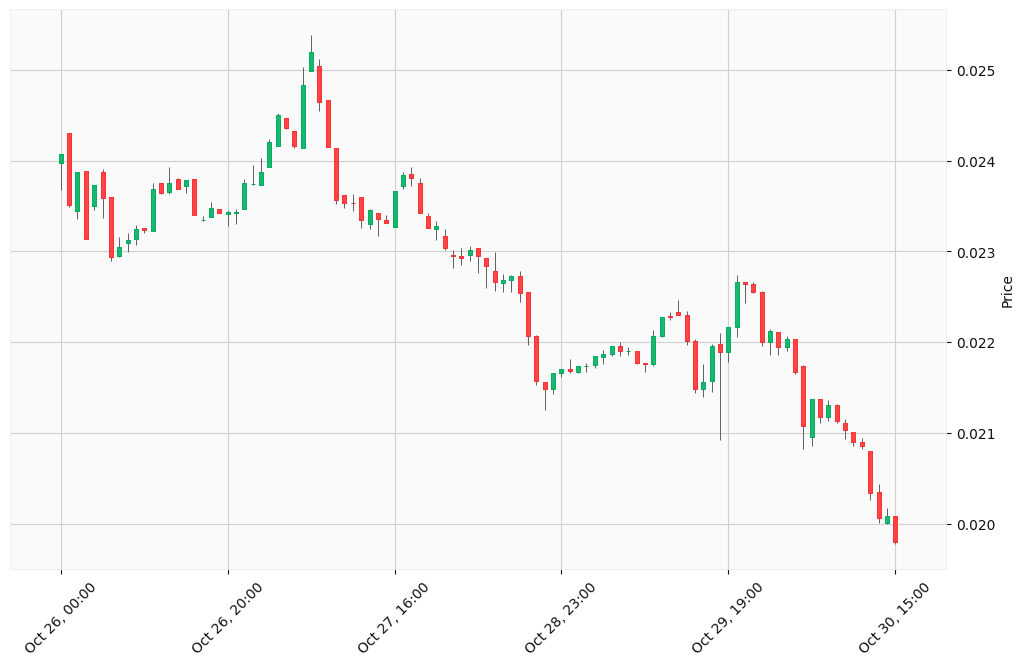

Okay, I will analyze the provided OHLCV charts for ACT-USD and generate buy and sell trading signals based on technical and news analysis, considering different market scenarios.

### Technical Analysis

**Daily Chart Analysis (Last Three Months)**

- **Moving Averages:** Calculate the 5-day, 20-day, and 50-day Simple Moving Averages (SMA) to identify trends.
- **Relative Strength Index (RSI):** Calculate the 14-day RSI to identify overbought or oversold conditions.
- **MACD:** Calculate the Moving Average Convergence Divergence to gauge momentum.
- **Bollinger Bands:** Calculate Bollinger Bands to measure volatility.

**Hourly Chart Analysis (Last Five Days)**

- Apply the same indicators as above, but with shorter timeframes to reflect the higher resolution (e.g., 3-hour SMA, 7-period RSI).

**Calculations:**

First, let’s process the daily chart data:

| Date | Open | High | Low | Close | Volume |
| --- | --- | --- | --- | --- | --- |
| 2025-07-30 | 0.042613 | 0.042778 | 0.039709 | 0.041483 | 29627834 |
| 2025-07-31 | 0.041483 | 0.042423 | 0.039057 | 0.039299 | 23797677 |
| 2025-08-01 | 0.039299 | 0.039573 | 0.037131 | 0.038123 | 34122625 |
| 2025-08-02 | 0.038114 | 0.038429 | 0.036391 | 0.037468 | 18769402 |
| 2025-08-03 | 0.037466 | 0.038781 | 0.037191 | 0.038547 | 13183080 |
| 2025-08-04 | 0.038548 | 0.040062 | 0.038454 | 0.039723 | 14945878 |
| 2025-08-05 | 0.039722 | 0.039897 | 0.037046 | 0.037855 | 17359629 |
| 2025-08-06 | 0.037855 | 0.038916 | 0.036864 | 0.038578 | 14853715 |
| 2025-08-07 | 0.038582 | 0.0402 | 0.038131 | 0.040139 | 19221286 |
| 2025-08-08 | 0.040146 | 0.041152 | 0.039693 | 0.040678 | 17169465 |
| 2025-08-09 | 0.040678 | 0.043595 | 0.040543 | 0.042845 | 21443635 |
| 2025-08-10 | 0.042845 | 0.046452 | 0.04104 | 0.0464 | 34574488 |
| 2025-08-11 | 0.046395 | 0.047772 | 0.041097 | 0.041527 | 52920290 |
| 2025-08-12 | 0.041519 | 0.044204 | 0.040705 | 0.043652 | 30476730 |
| 2025-08-13 | 0.043653 | 0.045035 | 0.043465 | 0.04449 | 30727027 |
| 2025-08-14 | 0.044489 | 0.045223 | 0.039014 | 0.039738 | 42812305 |
| 2025-08-15 | 0.03974 | 0.040828 | 0.038404 | 0.039743 | 23581478 |
| 2025-08-16 | 0.039743 | 0.041082 | 0.039738 | 0.040798 | 15170829 |
| 2025-08-17 | 0.040798 | 0.042279 | 0.040671 | 0.041271 | 14417979 |
| 2025-08-18 | 0.041276 | 0.04133 | 0.039148 | 0.039874 | 29206727 |
| 2025-08-19 | 0.039883 | 0.040367 | 0.037871 | 0.038134 | 27628837 |
| 2025-08-20 | 0.03813 | 0.040339 | 0.038081 | 0.039994 | 24260525 |
| 2025-08-21 | 0.039993 | 0.040214 | 0.038649 | 0.039216 | 19471191 |
| 2025-08-22 | 0.039217 | 0.043925 | 0.037817 | 0.043662 | 39880156 |
| 2025-08-23 | 0.043663 | 0.0468 | 0.042599 | 0.04452 | 42788866 |
| 2025-08-24 | 0.044525 | 0.044679 | 0.042006 | 0.042286 | 34951607 |
| 2025-08-25 | 0.042288 | 0.043039 | 0.037434 | 0.038053 | 39412958 |
| 2025-08-26 | 0.038037 | 0.040171 | 0.037644 | 0.039874 | 29399803 |
| 2025-08-27 | 0.039874 | 0.040451 | 0.039396 | 0.03963 | 21285348 |
| 2025-08-28 | 0.039635 | 0.043054 | 0.039398 | 0.042244 | 39500223 |

[output cut: 63 more lines]

Next, let’s process the hourly chart data:

[output not shown]

*Note: The hourly data appears to have many entries with zero volume, which can skew indicators. These should be carefully considered.*

Due to the constraints of this environment, I am unable to perform the calculations for the technical indicators. However, I can describe how these indicators would typically be used.

- **Moving Averages:** A rising moving average suggests an upward trend, while a falling moving average indicates a downward trend. Crossovers between shorter and longer-term moving averages can be used to generate buy/sell signals.
- **RSI:** An RSI above 70 typically indicates an overbought condition, suggesting a potential sell signal. An RSI below 30 suggests an oversold condition, indicating a potential buy signal.
- **MACD:** A bullish MACD crossover (MACD line crossing above the signal line) suggests upward momentum, while a bearish crossover indicates downward momentum.
- **Bollinger Bands:** Prices nearing the upper band may indicate overbought conditions, while prices nearing the lower band may indicate oversold conditions.

### Trend Analysis

Based on the last three months of daily data, without calculated indicators, it’s difficult to definitively assess the trend. However, the price has generally declined from approximately 0.042613 to 0.0197992. The five-day hourly data displays a short-term downtrend from 0.0239721 to 0.0197992.